# EDA on Prosper Loan Data

Napitupulu Jon

November 27, 2015

## Univariate Plot Section

```
##     Min.  1st Qu.   Median     Mean  3rd Qu.     Max.
##  0.00000  0.00000  0.00000  0.04228  0.00000 39.00000
```

```
##
##     0     1     2     3     4     5     6     7     8     9    14    16
## 87862  2438   403    78    23     8     3     3     2     5     1     2
##    21    24    39
##     1     1     1
```

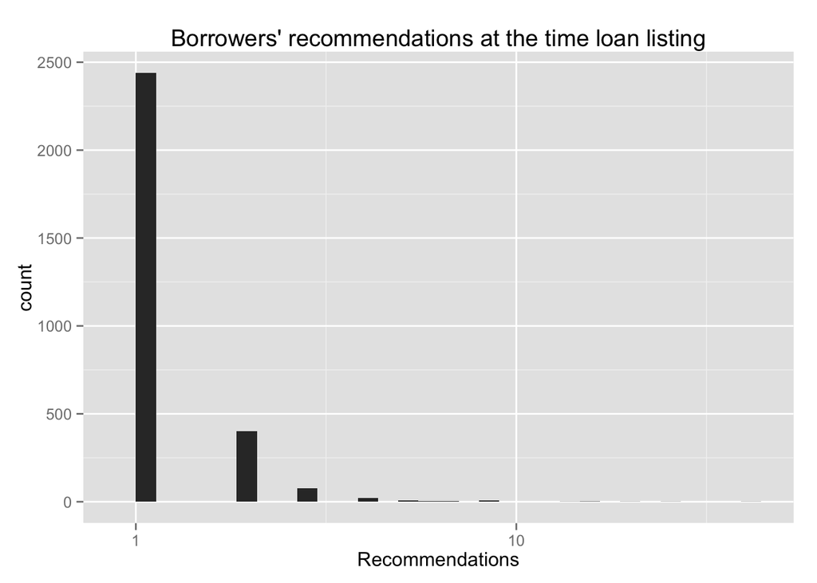

Recommendations: Number of recommendations.

This is the number of recommendations that Borrowers have when listing the loans. We can see that the number of the recommendations is right skewed, with the mean 0.04, which in average borrower doesn’t has many number of recommendations. And it goes as high as 39 recommendations for just one borrower.

I choose histogram as the chart as it depict the distribution of numerical variable. Since this is right skewed, I log scale the number of recommendations.

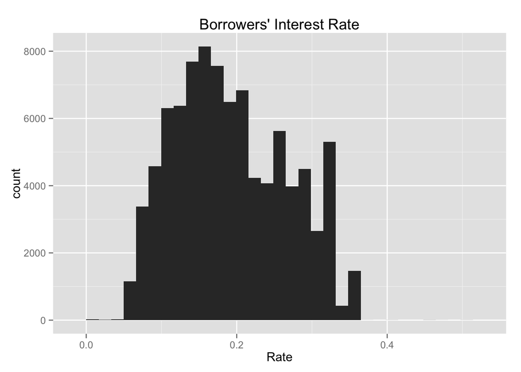

Rate: The Borrower’s interest rate for this loan.

The borrower’s rate follow almost unimodal distribution, with peak around 0.16. There’s spike occurs, around 0.3, but doesn’t make enough to be second peak.

```
##
##     1     2     3     4     5     6     7
##  5487  7521 10839 15224 12633 11081  4151
```

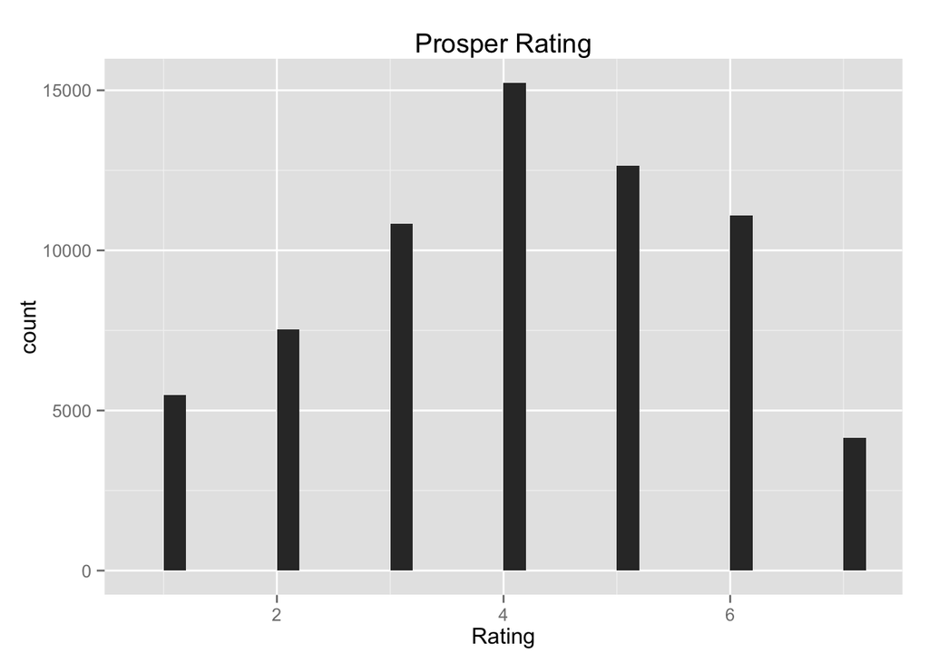

Rating : The Prosper Rating assigned at the time the listing was created between AA - HR. Applicable for loans originated after July 2009.

```
##
##     0     1     2     3     4     5     6     7     8     9    10    11
## 14398 47562  5242  5406  1851   561  1738  7903   150    64    76   179
##    12    13    14    15    16    17    18    19    20
##    44  1602   746  1117   253    41   669   597   632
```

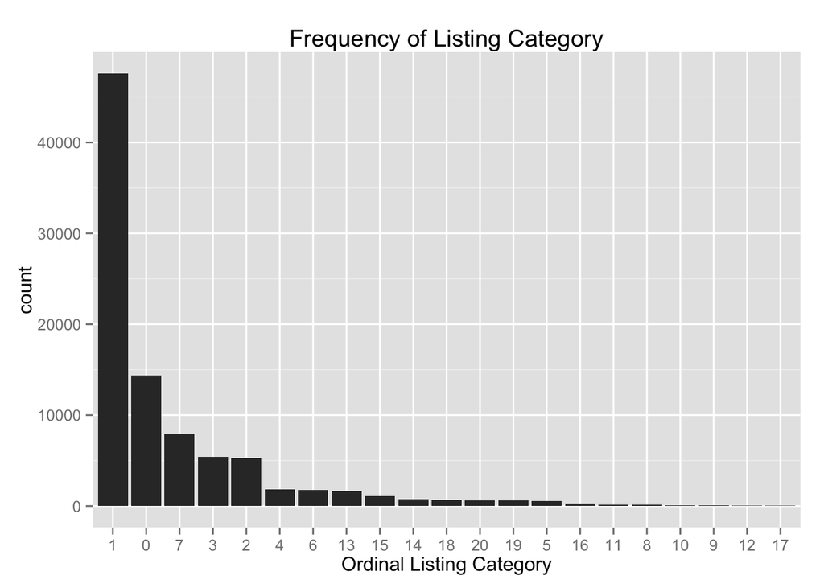

Category: The category of the listing that the borrower selected when posting their listing: 0 - Not Available, 1 - Debt Consolidation, 2 - Home Improvement, 3 - Business, 4 - Personal Loan, 5 - Student Use, 6 - Auto, 7- Other, 8 - Baby&Adoption, 9 - Boat, 10 - Cosmetic Procedure, 11 - Engagement Ring, 12 - Green Loans, 13 - Household Expenses, 14 - Large Purchases, 15 - Medical/Dental, 16 - Motorcycle, 17 - RV, 18 - Taxes, 19 - Vacation, 20 - Wedding Loans

```
## False  True
## 45292 45539
```

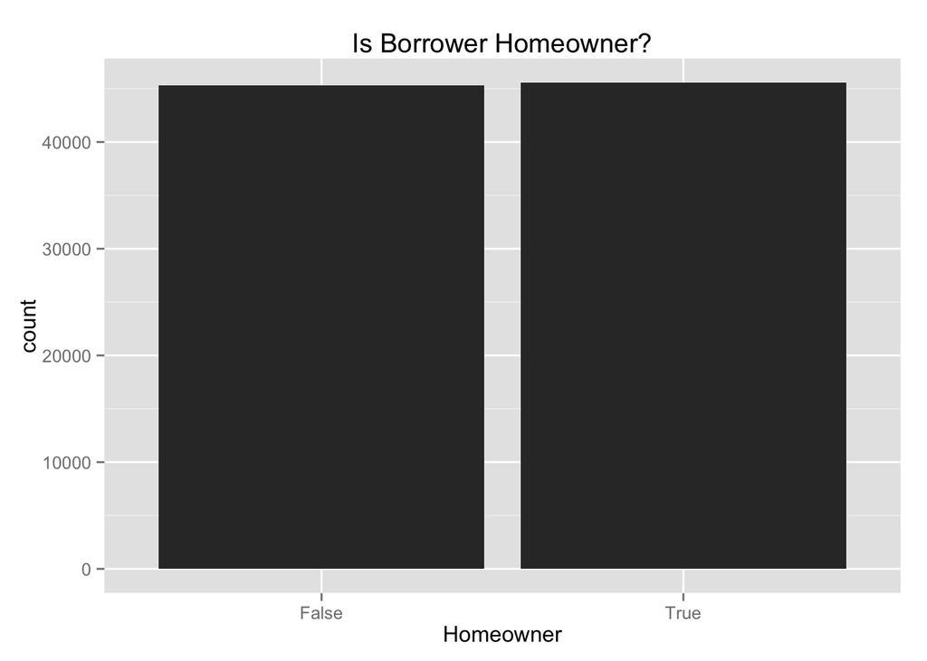

Homeowner: A Borrower will be classified as a homowner if they have a mortgage on their credit profile or provide documentation confirming they are a homeowner.

When looking at the loan that’s been listed, we see that borrower that is home owner is around equal proportion to those who do not. So it’s not affecting much.

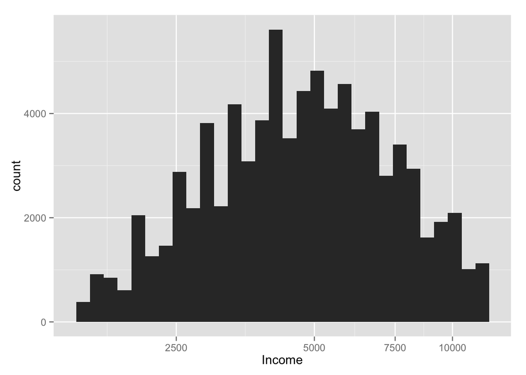

Income: The monthly income the borrower stated at the time the listing was created. Still we see that isn’t much going on with the monthly income.

Monthly Income will definitely be right skewed, since fewer people will have higher salary. So I cut the outliers and log 10 scale.

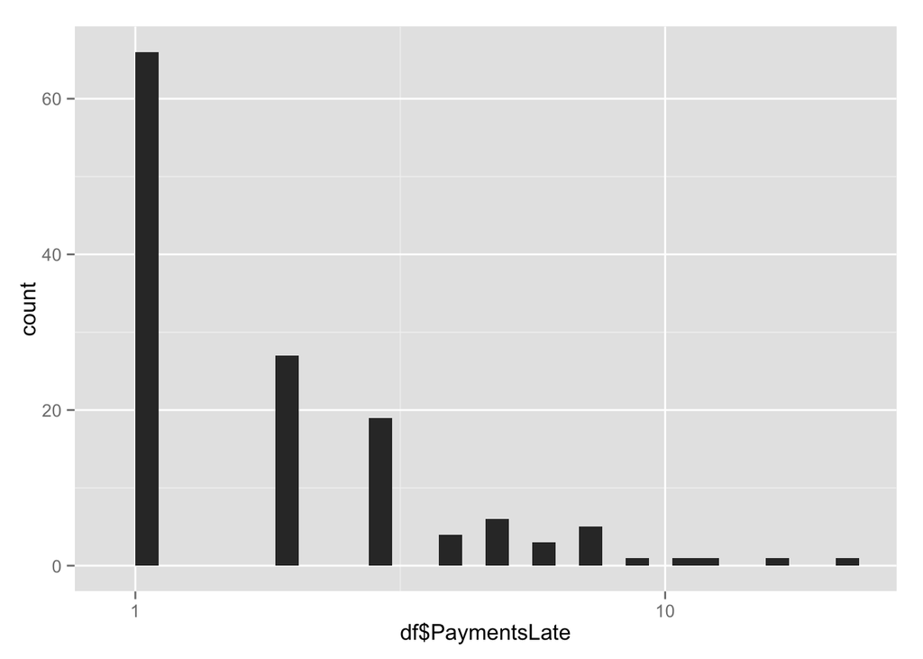

```
##
##    0    1    2    3    4    5    6    7    9   11   12   16   21
## 8445   66   27   19    4    6    3    5    1    1    1    1    1
```

PaymentsLate: Number of payments the borrower made on Prosper loans that were greater than one month late at the time they created this listing. This value will be null if the borrower had no prior loans.

Here’s we see that number of late payments is also very right skewed. Since this is number and not floating point, the number isn’t represent as smooth histogram.

Well looking at the frequency count, we see that most of the borrowers have no recommendations when they listing a loans. It may seems really hard to get recommendations in the listing loans, since we see that number only few people that can get at least higher than ten recommendations.

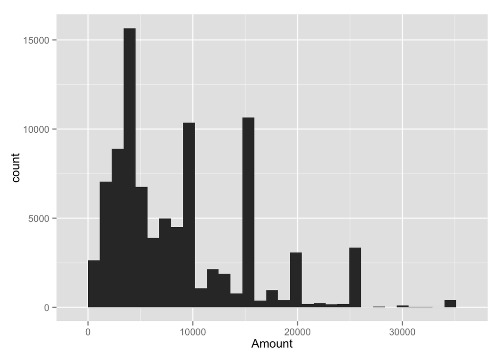

```
##    Min. 1st Qu.  Median    Mean 3rd Qu.    Max.
##    1000    4000    7000    8644   12500   35000
```

Amount: The origination amount of the loan.

```
##
##    12    36    60
##  1062 69530 20239
```

```
##    Min. 1st Qu.  Median    Mean 3rd Qu.    Max.
##   12.00   36.00   36.00   41.07   36.00   60.00
```

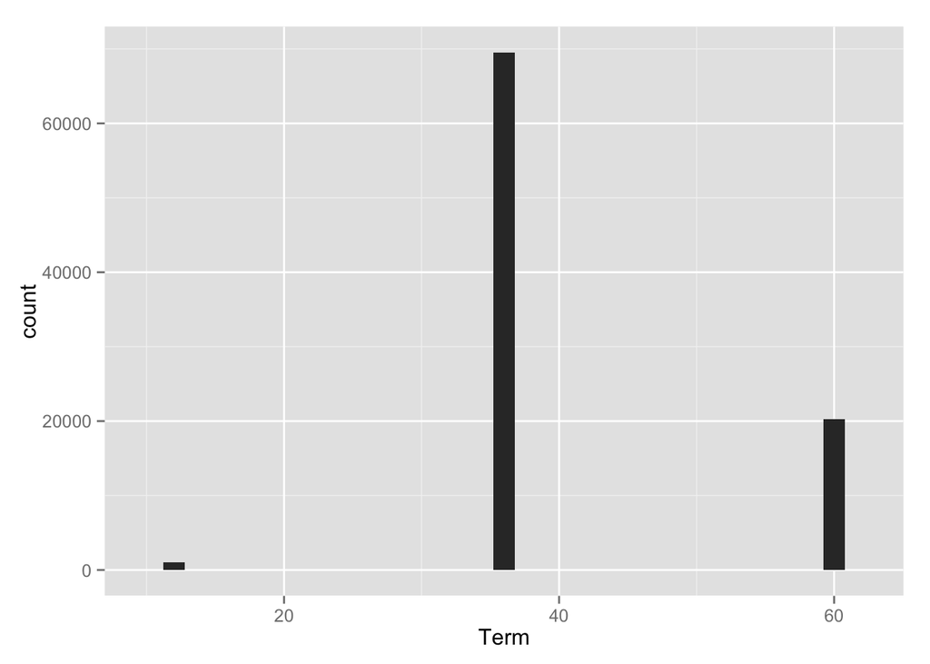

Term: The length of the loan expressed in months.

```
##
##                                                        Accountant/CPA
##                               3190                               2439
##           Administrative Assistant                            Analyst
##                               2912                               2748
##                          Architect                           Attorney
##                                162                                798
##                          Biologist                         Bus Driver
##                                 94                                275
##                         Car Dealer                            Chemist
##                                140                                116
##                      Civil Service                             Clergy
##                               1109                                159
##                           Clerical                Computer Programmer
##                               2558                               3301
##                       Construction                            Dentist
##                               1548                                 61
##                             Doctor                Engineer - Chemical
##                                402                                178
##              Engineer - Electrical              Engineer - Mechanical
##                                866                               1108
##                          Executive                            Fireman
##                               3400                                327
##                   Flight Attendant                       Food Service
##                                 95                                943
##            Food Service Management                          Homemaker
##                               1008                                104
##                           Investor                              Judge
##                                152                                 18
##                            Laborer                        Landscaping
##                               1343                                190
##                 Medical Technician                  Military Enlisted
##                                929                               1003
##                   Military Officer                        Nurse (LPN)
##                                250                                422
##                         Nurse (RN)                       Nurse's Aide
##                               2101                                437
##                              Other                         Pharmacist
##                              22931                                209
##         Pilot - Private/Commercial  Police Officer/Correction Officer
```

[output cut: 14 more lines]

```
##                                595                                 34
## Student - College Graduate Student           Student - College Junior
##                                185                                 90
##           Student - College Senior        Student - College Sophomore
##                                153                                 58
##        Student - Community College         Student - Technical School
##                                 19                                 15
##                            Teacher                     Teacher's Aide
##                               3002                                217
##              Tradesman - Carpenter            Tradesman - Electrician
##                                 98                                366
##               Tradesman - Mechanic                Tradesman - Plumber
##                                780                                 82
##                       Truck Driver                    Waiter/Waitress
##                               1423                                345
```

```
##
##               Other        Professional           Executive
##               22931               10368                3400
## Computer Programmer
##                3301                3190
```

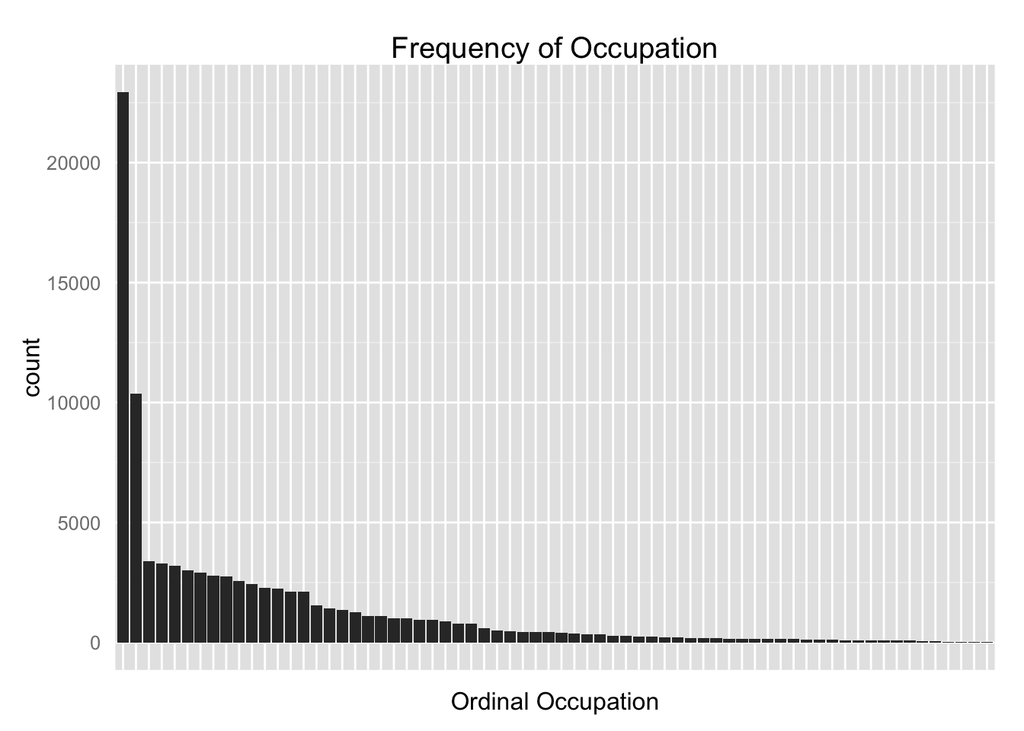

Occupation: The Occupation selected by the Borrower at the time they created the listing.

```
##              Cancelled             Chargedoff              Completed
##                      4                  10457                  25925
##                Current              Defaulted FinalPaymentInProgress
##                  48042                   4644                    155
##   Past Due (>120 days)   Past Due (1-15 days)  Past Due (16-30 days)
##                     13                    619                    204
##  Past Due (31-60 days)  Past Due (61-90 days) Past Due (91-120 days)
##                    297                    237                    234
```

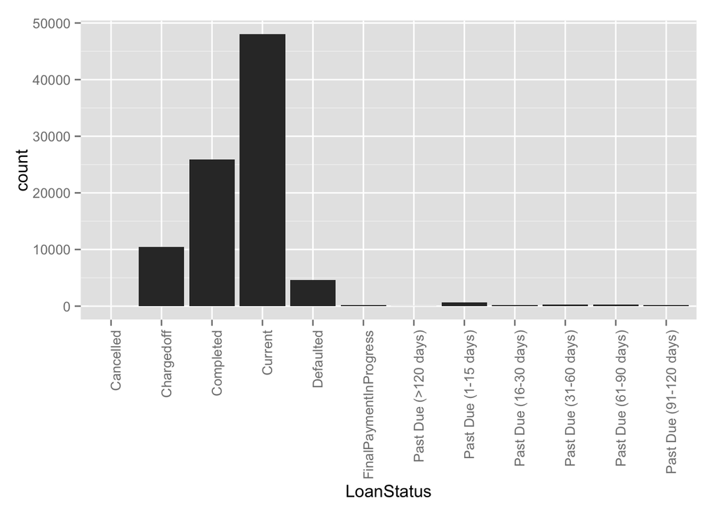

LoanStatus: The current status of the loan: Cancelled, Chargedoff, Completed, Current, Defaulted, FinalPaymentInProgress, PastDue. The PastDue status will be accompanied by a delinquency bucket.

```
##    Min. 1st Qu.  Median    Mean 3rd Qu.    Max.
##  0.7000  1.0000  1.0000  0.9985  1.0000  1.0040
```

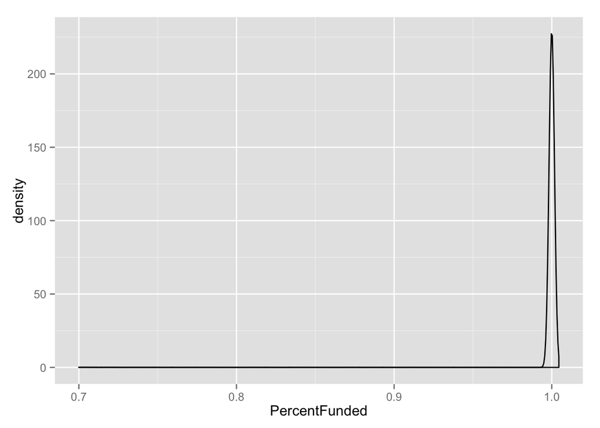

PercentFunded: Percent the listing was funded.

```
##
##           A    AA     B     C     D     E    HR    NC
## 67003  2711  2893  3500  4474  4188  2782  3148   132
```

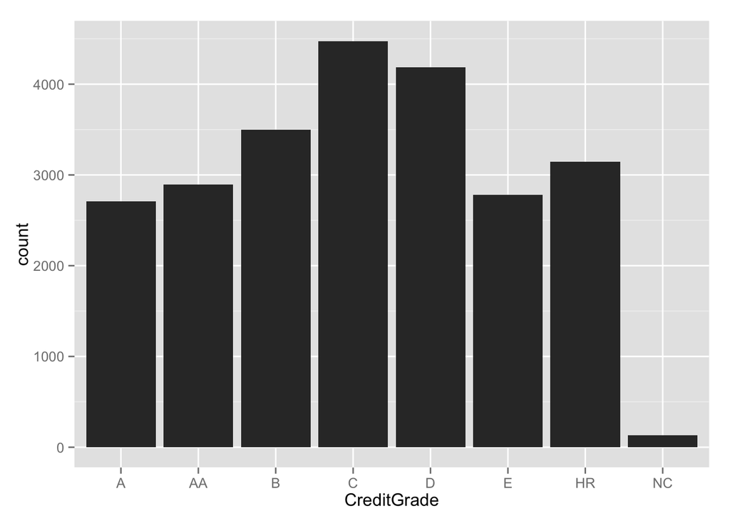

CreditGrade: The Credit rating that was assigned at the time the listing went live. Applicable for listings pre-2009 period and will only be populated for those listings.

This is essentially the same as Prosper Rating except that credit grade is rating given to loans pre-2009 and ProsperRating given after 2009. While looking at the frequency table we see that credit grade fill with empty value, that is the loans listed after July 2009. Since in this plot we only want to see credit grade, I exclude the loans listed after that date. What I can see now is Credit Grade that shown like a normal distribution(I can infer that since this is ordinal categorical), centered at C. NC is an outlier, which in this case “No Score”.

# Univariate Analysis

### What is the structure of your dataset?

Other observations:

### What is/are the main feature(s) of interest in your dataset?

The main features of the dataset is the Prosper rating. I like to what are features among these 13 that will best play as predictor for the Prosper rating.

### What other features in the dataset do you think will help support your investigation into your feature(s) of interest?

I want to test the features that only exist when borrower listing the loans. Features like income, loan, occupation, listing category, recommendations, borrower rate, whether borrowers is home owner, number of payments late, and term is features that I like to get better idea for seeing whether the features contribute to predict posper rating. Because prosper rating is the feature of interest, I exclude the missing value of prosper rating for bivariate analysis.

### Did you create any new variables from existing variables in the dataset?

For this dataset, I don’t create new feature.

### Of the features you investigated, were there any unusual distributions? Did you perform any operations on the data to tidy, adjust, or change the form of the data? If so, why did you do this?

There is unusual features in this dataset, in particular, monthly income. This is stated(human input) by the borrowers. As such, we see many unusual salary. there’s borrower who’s stated their monthly income close to two millions but makes 35000 dolars loan. There’s also person who who makes 0 dolars monthly salary. So I tidy the features by excluding 5% below and 95% above. We know that income will be long tail right skewed, and the distance will be very far among salary. So I use log 10 transformations. The result after excluding outliers and log 10 transformation produces normal distribution.